# Tema 2: Introducció a l’inferència estadística

## Mostreig aleatori en poblacions finites

Som inversors immobiliaris a Barcelona i volem tenir una estimació del preu mig de venta dels habitatges sense esperar a que l’ajuntament publiqui les dades de les compra-ventes registrades en l’[últim exercici](https://opendata-ajuntament.barcelona.cat/data/ca/dataset/est-mercat-immobiliari-compravenda-preu-total).

Òbviament, fer una investigació per tal de conèixer els valors de totes les transaccions seria molt costós: hauriem de tenir contactes amb totes les agències immobiliaries i convencer-les de que ens facilitin aquesta informació.

Un amic estadístic ens ha dit que en realitat no fa falta que sàpiguem el valor de totes les transaccions, sino que podem fer servir la màgia de l’estadística per caracteritzar-ne la mitja a través d’una **mostra aleatòria**.

Com que no ens el creiem massa, decidim fer alguns experiments per veure si el que diu és veritat. Per això, ens hem descarregat les dades dels preus de venta d’habitatges del primer trimestre de 2019:

```r
comp_vend_preu_trim <- read.csv("~/Downloads/2019_comp_vend_preu_trim.csv")

# Considerem només les files corresponent als valors totals i convertim els preus a dades numèriques
preus = as.numeric(subset(comp_vend_preu_trim, Preu_mitja_habitatge=="Total. Milers d'euros")$Valor)
```

La quantitat que volem aproximar és la mitjana del preu de venta:

```r
mu = mean(preus, na.rm = TRUE) # excloem alguns valors NaN que venen de les dades originals
```

Això és el que anomenarem el **paràmetre de la població** ($\mu$=317.63125 - en milers d’euros) o el moment de la població, que calculem a partir de **tots** els valors de la **població**, en aquest cas n’hi ha 272. Aquest és un exemple de **població finita** (el conjunt de totes les ventes efectuades en un trimestre és finit).

El nostre amic estadístic ens ha dit que en realitat en tindriem prou amb **estimar** $\mu$ mitjantçant la mitjana aritmètica (que ell anomena un **estadístic**):

$\hat{\mu} = \bar{x} = \frac{1}{n}\sum_{i=1}^n x_i$,

amb n=30 mostres enlloc de 272. És una reducció d’un factor de 10!

Concretament, ens diu que l’arrel quadrada de l’error quadràtic mitjà de l’**estimador** $\hat{\mu}$ del paràmetre d’interès $\mu$ (la mitja de la població) construït a partir de la **mitjana aritmètica** de només 30 mostres, serà de l’ordre del 10%:

$\sqrt{E(\bar{\mu} - \mu)^2} / \mu \approx 0.1$

Com que no ens en fiem massa, decidim provar-ho computacionalment. Per fer-ho, repetirem $N=1000$ cops el següent experiment: agafarem una mostra de $n=30$ elements de les nostres dades, en calcularem l’**estadístic mitja aritmètica** $\bar{\mu}$ i l’error quadràtic d’aquesta respecte a $\mu$. Finalment, estimarem l’error quadràtic mitjà com la mitjana aritmètica d’aquests errors quadràtics:

```r
N = 1000
n = 30
mu_bar = rep(0, N)
error = rep(0, N)
for (i in 1:N){
    mu_bar[i] = mean(sample(preus, n), na.rm=TRUE)
    error[i] = (mu_bar[i] - mu)^2
}

sqrt(mean(error)) / mu
```

```
## [1] 0.1071594
```

Vaja… doncs sembla que l’estadístic tenia raó… L’error típic dels nostres estimadors amb només 30 mostres és de menys de l’11%… Però no només és l’error típic bastant petit, sino que els nostre estimador no tenen gairebé **biaix** :

```r
mean(mu_bar) - mu
```

```
## [1] -0.3018342
```

I la seva desviació estàndard és gairebé igual a $\frac{\sigma}{\sqrt{n}}$, on $\sigma$ és la desviació estàndard de la població… coincidència?

```r
sigma = sd(preus, na.rm = TRUE)

sd(mu_bar)
```

```
## [1] 34.05285
```

```r
sigma/sqrt(n)
```

```
## [1] 34.42573
```

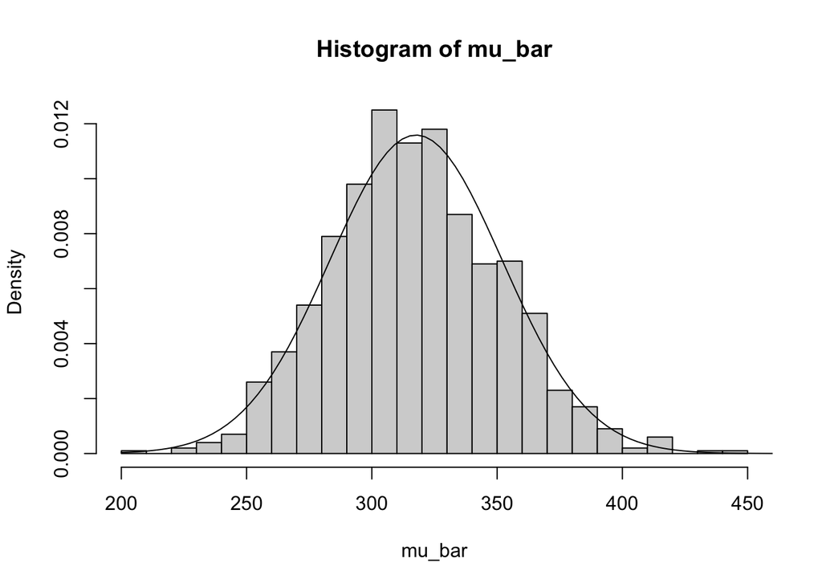

```r
hist(mu_bar, 20, prob=T)
z = seq(200, 500, length=100)
f = dnorm(z, mu, sigma/sqrt(n))
lines(z, f)
```

## Conclusió

Què son aquestes propietats tan curioses de la mitja aritmètica d’una mostra tan relativament petita? Com pot ser que la distribució d’aquest estadístic s’assembli tant a una Gaussiana? S’exténen aquestes propietats a d’altres estadístics com la mediana o el màxim/mínim?

El que acabem de veure són exemples de l’importància dels primers resultats que veurem en inferència estadística: hem pogut caracteritzar el **paràmetre d’una població** (el preu mitjà) a través d’un **estadístic** calculat a partir d’un nombre finit i petit de mostres! La teoria que veurem a continuació ens permetrà caracteritzar les propietats d’aquest i d’altres estadístics, per tal d’avaluar-ne, a priori, la seva capacitat de capturar les propietats d’una població.